# Home

Econometrics | Causal Inference | Applied Microeconomics

I am an Assistant Professor of Economics at the University of Alabama’s Culverhouse College of Business.

My research is in econometrics, with interests in causal inference, estimation, inference, hypothesis testing, and uniform inference. I develop methods that help researchers make more credible empirical claims, especially in settings with complex data, weak identifying assumptions, and challenging inference problems. My work combines theory with applied questions in economics.

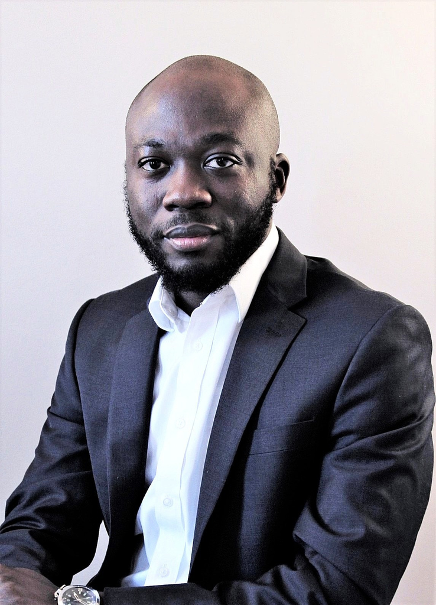

### Quick links

Research Curriculum Vitae Code

### Contact

**Emmanuel S. Tsyawo**  
Assistant Professor of Economics  
Culverhouse College of Business, University of Alabama

Email: estsyawo [at] gmail.com  
[GitHub](https://github.com/estsyawo)

### Recent updates

- New publication: [Distributional Effects with Two-Sided Measurement Error: An Application to Intergenerational Income Mobility](https://www.sciencedirect.com/science/article/pii/S0304407626000898), with Brantly Callaway, Tong Li and Irina Murtazashvili, *Journal of Econometrics* (2026).
- Recent publication: [Difference-in-differences with as few as two cross-sectional units – A new perspective to the democracy-growth debate](https://www.tandfonline.com/eprint/GA9C4VHPMCHGYDFRXRTD/full?target=10.1080/07474938.2026.2670372#abstract), with Gilles Koumou, *Econometric Reviews* (2026).
- New working paper: [A Grid-Rate Condition for Valid Uniform Inference](https://arxiv.org/pdf/2605.12284) (2026).
- New R package: icmkit provides tools for Integrated Conditional Moment (ICM) estimation and specification testing in linear and nonlinear regression settings.

### Scheduled presentations

- Florida State University, Tallahassee, FL (September 11, 2026).
- [Midwest Econometrics Group Annual Meeting](https://www.business.uc.edu/faculty-research/economics/research/meg-2026.html), Cincinnati, OH (October 9-10, 2026).
- Ohio State University, Columbus, OH (October 12, 2026).
- [Southern Economic Association Annual Meeting](https://southerneconomic.org/conference/), Houston, TX (November 21-23, 2026).